# SQUIDSIM, SQUID SIMULATOR, Version 1.32, SPRFMO SC13

Ignacio Payá C., IFOP, Chile

febrero 17, 2025

##### 0.0.0.0.1

# 1 SUMMARY

SQUIDSIM is a program designed to simulate individual, population, and fishery components of Humboldt Squid stock over the years on a monthly scale. Natural mortality is estimated using the gnomonic method (Caddy, 1996), with five gnomonic stages, longevity, and fecundity. Three growth functions (exponential, Von Bertalanffy, and Gompertz) are included. Maturity is modeled as a logistic function. Three options for modeling the stock-recruitment relationship (Ricker, Beverton and Holt,and Shepherd) with steepness parameters and process errors are included. Three options (constant, exponential, and sinusoidal) for seasonal recruitment patterns are included. The fishing components include four fleets with selectivity patterns modeled as double half-normal functions. A length-age key is calculated based on the growth model to estimate the mantle length frequency in the population and in the commercial catches. Seven abundance indices are included: four commercial CPUE (with hyperstability), two acoustic biomass surveys, and an egg production survey. The selectivity curves of the acoustic surveys are modeled by length using double half-normal functions.

This simulator was coded in R Mardown in R Studio, which allows to automatically knit text, R codes, tables and figures to produce a report in html, word, and pdf formats. In order to run the simulation with different cases, the parameters must be input in a csv format file.

# 2 INTRODUCCTION

The Scientific Committee seems to agree that because of the short lifetime (1 -2 year) of Humboldt squid, the stock assessment and management should be done in-season scale. However, the impact of not doing so and try to apply models with year scale, as the global production models, has not been formally evaluated.

Management strategy evaluation requires to build an operational model to test different stock assessment models and harvesting rules. The simulation of the stock dynamics and the fisheries is the first step in development an operational model. Therefore, this contribution offers a simulator of the population dynamic and fishery of Humboldt squid stock.

From the point of view of the local squid stock assessment in the EEZ of Chile, the simulator should be able to reproduce the mantle length frequencies observed by month in artisanal catches in 2015 (broken line) and 2016 (solid line)(I. Payá 2015, 2016).

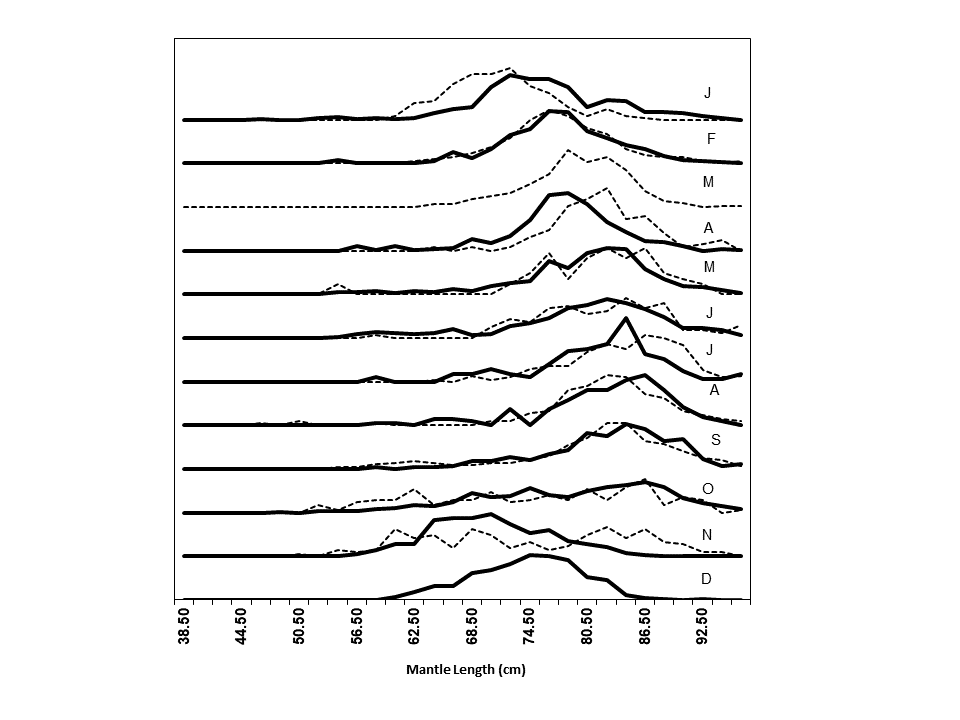

These frequencies had a clear modal progression that suggests the arrival of large squids in November and the departure in October of the next year (I. Payá 2016). This mantle length data combined with abundance indices have been used in fitting successfully local depletion models (I. Payá 2015, 2016, 2017, 2019).

The version 1.0 was designed to simulate the dynamic of Humboldt Squid population in Chilean waters (I. Payá 2019). The simulations were done through years using a monthly step. The recruitments were modelled using a Ricker (1954) or a Beverton and Holt (1957) stock-recruitment relationship, with a steepness parameter (h) (Mace and Doonan 1988) and process errors (rsigma). Recruitment could be multiply by a seasonal factor to generate a seasonal pattern. Seasonal pattern can be constant (no effect), exponential decreasing or sinusoidal. The fishing component includes two fleets. The fishing selectivity were modeled as double half-normal functions.

The version 1.1 (I. Payá 2023) extended the squid simulator to the FAO area 87. It added four abundance indices: two CPUE indices (with or without hyperstability) and two acoustic biomasses. Selectivity curves of the acoustic surveys were modelled by length using double half-normal functions. Also, adds a new option for seasonal recruitment pattern, new charts and improvements to some others charts.

The version 1.2 (I. Payá 2024) added 1) the longevity and the fecundity parameters to estimate the natural mortality using gnomonic method (Caddy 1996), and 2) a third commercial fishery.

The current version 1.3 adds a fourth commercial fisheries and the Gompertz (1825) growth model as a third option for growth models.

This simulator is coded in R Mardown in R Studio (Allaire et al. 2018). The individual, population and fishery parameters are setting in a file named “HSquid_Par.csv”. The use of external parameter file allows to run the simulation with different set of parameters.

##### 2.0.0.0.1

# 3 METHODS

The age and time variables are in units of years. The $bin$ is the fraction of the year and $nbin$ is the number of bins in a year, for example for a month fraction $bin=1/12$. The time $j$, $j=1,.....nbtins$, where $nbtins$ is the whole numbers of months in the time series. The age $i$, $i=1,...,nags$, where $nags$ is numbers of months in the lifetime (longevity).

## 3.1 INDIVIDUAL FUNCTIONS

### 3.1.1 Growth models

There are three model options. If gm=1 the exponential model is used:
$$l_{i} = a_{expo}exp(b_{expo}t)$$
where $l$ is the Mantle length (cm) and $a_{expo}$ and $b_{expo}$ are the parameters, which were taken from Argüelles et al. (2001) for large squid with hatching in spring.

If gm=2 the vonBertalanffy model is used:
$$l_{i} = loo(1-exp{(-r(t-t_{0}))}$$
where $loo$: Infinite length (cm); $r$: growth rate; $t$: age in years; $t0$: age in years at length zero;

If gm=3 the Gompertz model is used:
$$l_{i} = a_g * exp(- b_g * exp(-c_g * t))$$

### 3.1.2 Allometric growth

$$w_{i}= al_{i} ^{b }$$
where $a$ and $b$ are the allometric parameters and $w$ is the whole weight.

The vonBertalanffy parameters and the allometric parameters were taken from Payá I. et al. (2014).

### 3.1.3 Maturity at age

$$pm_{i} = 1/(1 +
exp{(-log(19)(i-im50)/imrange)) }$$
where $im50$ is the age at 50% of maturity and $imrange$ is the amplitude of the function.

## 3.2 POPULATION FUNCTIONS

### 3.2.1 Natural Mortality (M)

M is estimated using the Caddy (1996) gnomonic method and the R package gnomonicM of Torrejon-Magallanes (2021). Following to Martínez-Aguilar et al. (2010), the number of gnomonic intervals is fixed to 5 and the duration of the first interval (egg) is fixed to 6 days, while longevity and fecundity are input parameters. M is equal to adult mortality.

$$M_{i,j}=M_{bin} + e^{M}_{i,j}$$
where $e^{M} \sim N(0,sd_{M})$ and $sd_M$ is the standard deviation of $Mbin$

### 3.2.2 N at the first month

The recruitment before the first year is a vector of length equals to numbers of ages -1 (nags-1)
$$predR_{i}=R0
\quad exp(e^{0}_{i})$$
$$e^{0}_{i}
\sim N(0,prevrsigma)$$

where $prevrsigma$ is the standard deviation of recruitments before the starting month.

The number at age 1 at the first month is R1
$$N_{1,1}=R1$$
and for the older ages (i>2) is the number of survivors of previous recruitments
$$N_{i,1} = predR_{nags-1-i} \quad
exp(-M_{i-1,1}(i-1)) \quad exp({e^{0}_{i}})$$

### 3.2.3 Seasonal Recruitment Patterns

Constant pattern ($RSeason$=1):
$$inbinR=1 \quad exp(e^{s}_{1})$$
Exponential pattern ($RSeason$=2), with $inbinR_{1}=1$:
$$inbinR_{i}=exp(-0.20(i-1))\quad exp(e^{s}_{i})
\quad \quad for \quad i=2,...,12$$
Sinusoidal Pattern, two peaks in a year ($RSeason$=3):
$$inbinR_{i}= \sin(3+i) \quad exp(e^{s}_{i}) \quad
\quad for \quad i=1,...,12$$
Sinusoidal Pattern, one peak in a year ($RSeason$=4):
$$inbinR_{i}= \sin(8.5+i/2) \quad exp(e^{s}_{i})
\quad \quad for \quad i=1,...,12$$
$$e^{s} \sim N(0,SdSeason)$$
Non negative $inbinR_{i}$ were not allowed, so if $inbinR_{i}$<0 then $inbinR_{i}$=0. This seasonal pattern is similar to the one described by Tafur et al. (2019), with main spawning period en october to janaury.

### 3.2.4 Figure 1. Seasonal recruitment pattern options.

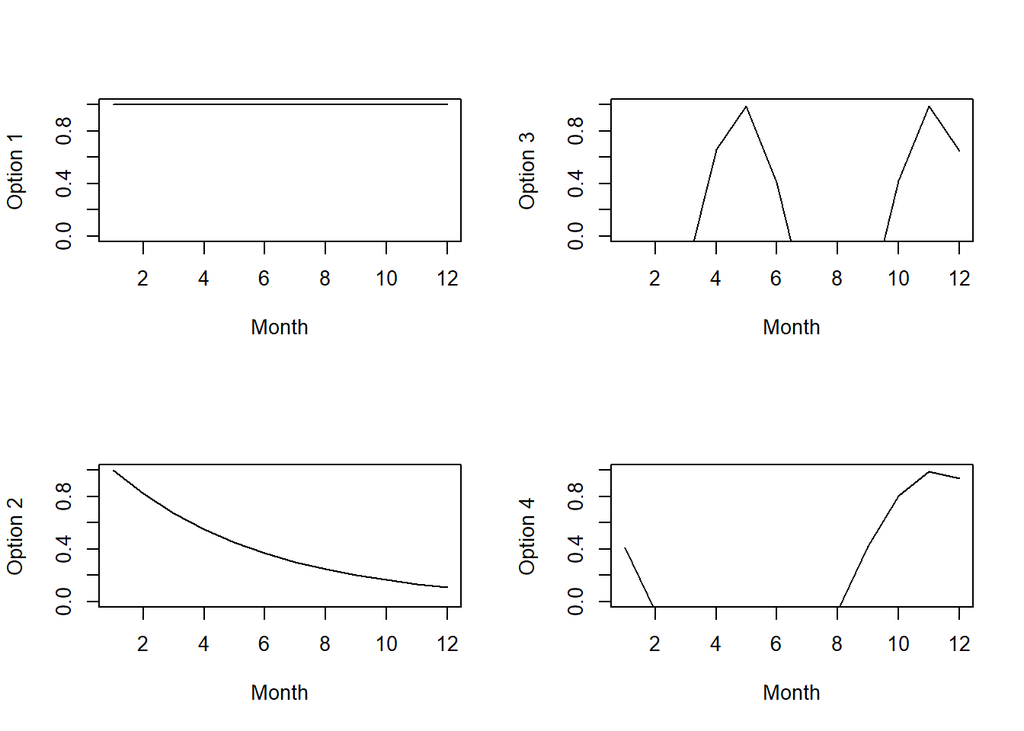

### 3.2.5 Equilibrium functions

The numbers per recruit ($Neq_{1}=1$), are :
$$Neq_{i} = Neq_{i-1}exp(-M_{i-1,1}) \quad \quad
for \quad i=2,...,nags$$
The potential spawning biomass per recruit, $SPBR$, in tons:
$$SBPR=\sum_{i=1}^{nags}
w_{i}mat_{i}Neq_{i}/1000$$
For $SB0$ (in tons) $R0$ is:
$$R0=SB0/SBPR$$
There are three options for the stock-recruitment model: 1) Ricker; 2) Beverton-Holt and 3) Shepherd.

The Ricker parameters are calculated based on the steepness parameter $h$ are:
$$alpha=1.25log(5*h)-log(SBPR)$$
$$beta=\frac{1.25log(5h)}{SB0}$$
The Beverton-Holt parameters based on steepness parameter $h$ are:

$$alpha=(1-h)/(4h) \quad SBPR$$
$$beta=(5h-1)/(4h \quad SB0) \quad
SBPR$$
Shepherd (1982) stock-recruitment model parameterized for steepness are:
$$a = \frac{1.0+(\frac{SB0}{b})^c}{SBPR}$$
$$b = SB0 (\frac{0.2-h}{h (0.2)^c - 0.2})^
(\frac{-1.0}{c})$$

The recruitment at the first month $j$=1, using Ricker model is calculated as:
$$R_{1}=N_{1,1}= SB0 exp(alpha-beta*SB0)
\quad inbinR_{j} \quad exp(e^{r}_{j}-rsigma^2/2)$$
while with Beverton-Holt model as:
$$R_{1}=N_{1,1}=SB0/
(alpha+betaSB0) \quad inbinR_{j} \quad exp(e^{r}_{j}-rsigma^2/2)$$
and with Sheperd model:
$$R_{1} =
\frac{a SB0}{1+(\frac{SB0}{b})^c} \quad exp(e^{r}_{j}-rsigma^2/2)$$
where $e^{r}_{j}$ is:
$$e^{r}_{j}\sim N(0,rsigma)$$

### 3.2.6 Population after the first bin (j= 2,… nbins).

The number $N_{i,j}$ are:

$$N_{i,j}=N_{i-1,j-1}exp(-M_{i,j}-F_{i,j})$$
The whole number by bin (year.month), $NT$(tons), is:
$$NT_{j}=\sum_{i=1}^{nags} N_{i,j}$$
The whole biomass by month, $BT$(tons), is:
$$BT_{j}=\sum_{i=1}^{nags}
N_{i,j}w_{i}/1000$$
The spawning biomass, $SBT$(tons), is calculated as:
$$SBT_{j}=\sum_{i=1}^{nags} N_{i,j}
mat_{i}w_{i}/1000$$
where, $mat_{i}$ is the maturity at age.

The recruitment, $R_{j}$, with Ricker model is:

$$R_{j}=N_{1,j}= SBT_{j-nags}
exp(alpha-betaSBT_{j-nags}) \quad inbinR_{j} \quad
exp(e^{r}_{j}-rsigma^2/2)$$
while with Beverton-Holt is:
$$R_{j}=N_{1,j-nags}=SBT_{j-nags}/
(alpha+betaSBT_{j-nags}) \quad inbinR_{j} \quad
exp(e^{r}_{j}-rsigma^2/2)$$
and with Shepherd stock-recruitment model:
$$R_{j} = \frac{a
SBT_{j-nags}}{1+(\frac{SBT_{j-nags}}{b})^c} \quad inbinR_{j} \quad
exp(e^{r}_{j}-rsigma^2/2)$$

To estimate the length frequency an age-length key,$alkey$ , is calculated assuming a normal distribution of length at age:

$$alkey_{i,j}= \frac{1}{{\sigma_{i} \sqrt
{2\pi } }}e^{-(ls_{j}-l_{i})^2/2\sigma_{i}^2}\quad for \quad
i=1,...,nags; \quad j=1,...,nls$$
where $ls_{i}$ is the mean length at age and $\sigma_{i}$ is the standardt deviation at age. $\sigma_{i}$ = $ls_{i}$*$CVGrowth$

The number at length ($k$) and month ($j$), $N_{k,j}$, is calculated as:

$$N_{k,j}=\sum_{i=1}^{nags} (N_{i,j} \quad
* \quad alkey_{k,i})$$

## 3.3 FISHERY FUNCTIONS

### 3.3.1 Selectivity and Fishing mortality.

Selectivity, $S$, are modelled by fleet ($f$) using double half-normal functions:
$$S^f_{i}=
exp(-0.5(i-bs^f)^2)/{as^f}^2) \quad \quad for \quad i<sb^f.$$
$$S^f_{i}= exp(-0.5(i-bs^f)^2)/{cs^f}^2)
\quad \quad for \quad i=>sb^f.$$
where $as, bs$ and $cs$ are parameters. $bs$ is the age of maximun selectivity ($S^f_{bs}=1$)

The fishing mortality,$F$, by fleet ($f$) at age and month is calculated as:
$$F^f_{i,j}=F^f_{ref}bin
\quad S^f_{i}$$
The whole fishing mortality is:
$$F_{i,j}=\sum F^f_{i,j}$$

### 3.3.2 Catch

Catch, $C$, by fleet ($f$) in numbers at age ($i$) and month ($j$):
$$C^f_{i,j}
=F^f_{i,j}/(F_{i,j}+M_{i,j})N_{i,j}(1-exp(-M_{i,j}-F_{i,j}))$$
Catch in number by fleet ($f$) at length ($k$) and month ($j$) is calculated as:
$$C^f_{k,j}=\sum_{i=1}^{nags} (C^f_{i,j} \quad *
\quad alkey_{k,i})$$
The whole catches in numbers are:
$$C_{i,j}=\sum C^f_{i,j} \quad \quad ; \quad
C_{k,j}=\sum C^f_{k,j}$$
The catch (tons) by fleet, $YT^f$(tons), is:
$$YT^f_{j}=\sum_{i=1}^{nags}
C^f_{i,j}w_{i}/1000$$
The whole catch (tons) is:
$$YT_{i,j}=\sum YT^f_{i,j}$$

## 3.4 ABUNDANCE INDICES

### 3.4.1 CPUE

$CPUE$ by fleet ($f$) and month ($j$) is:
$$CPUE^f_{j}=q^f(\sum_{i=1}^{nags}
(C^f_{i,j}w_{i}/1000)/F^f_{i,j})^{hyp}$$

### 3.4.2 Acoustic Selectivity.

Acoustic selectivity ($S$) by length ($l$) are modelled by survey ($f$) using double half-normal functions:
$$S^f_{l}=
exp(-0.5(l-bs^f)^2)/{as^f}^2) \quad \quad for \quad l<sb^f.$$
$$S^f_{l}= exp(-0.5(l-bs^f)^2)/{cs^f}^2)
\quad \quad for \quad l=>sb^f.$$
where $as, bs$ and $cs$ are parameters. $bs$ is the length at the maximun selectivity ($S^f_{bs}=1$)

### 3.4.3 Acoustic Biomass

Acoustic Biomass ($Bacous$) by survey ($f$) and month ($j$) is:
$$Bacous^f_{j}=qacous^f_{j}\sum_{i=1}^{nls}S^f_{l,j}
N_{l,j}w_{l}/1000$$

##### 3.4.3.0.1

# 4 RESULTS

The results are presented in graphs and then the parameters in tables.

## 4.1 INDIVIDUAL FUNCTIONS

### 4.1.1 Figure 2. Growth at size and age.

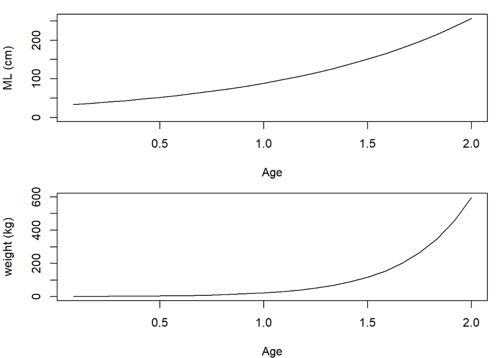

### 4.1.2 Figure 3. Maturity at age.

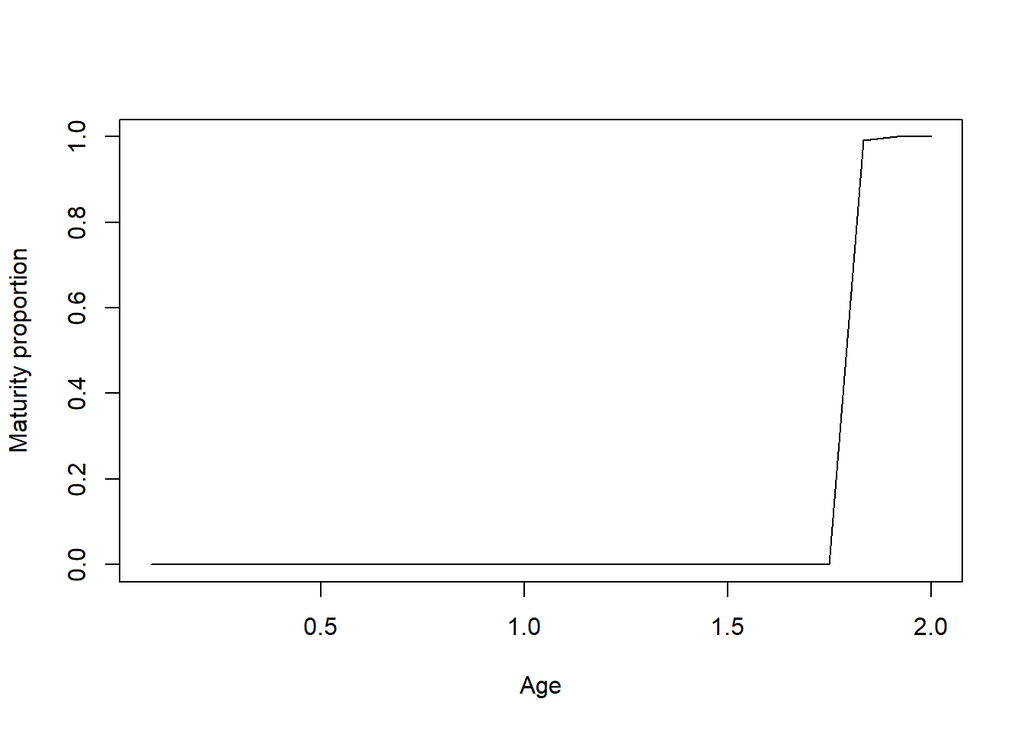

##### 4.1.2.0.1

## 4.2 POPULATION FUNCTIONS

```
## --------------------------------------------------------
##
## No additional information. You are only considering the egg stage duration = 6
##
## --------------------------------------------------------
```

### 4.2.1 Figure 4. Gnomonic stage natural mortality and duration

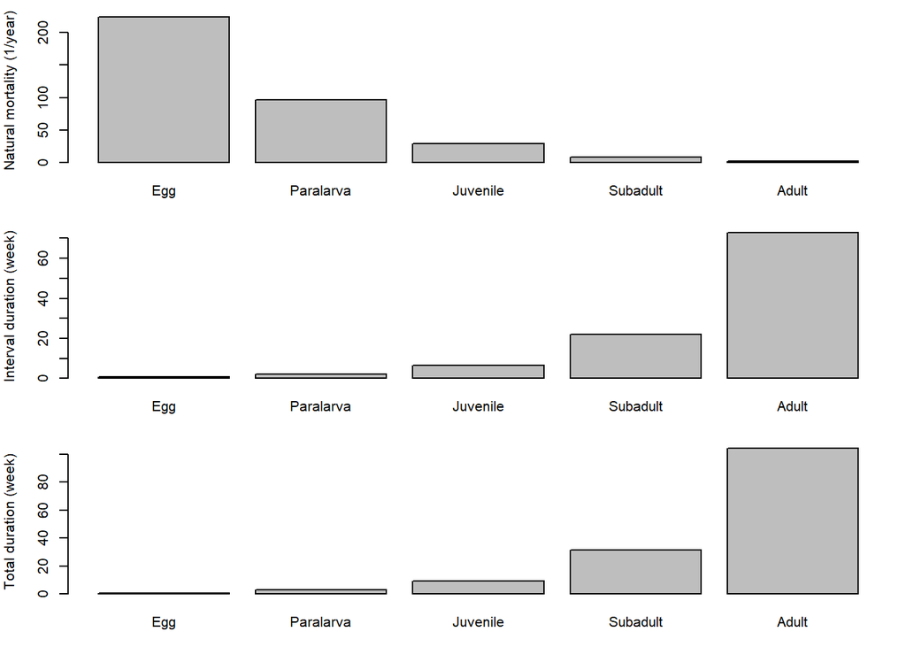

### 4.2.2 Figure 4b. M by age and YEAR.MONTH (if M is constant value then a plain color).

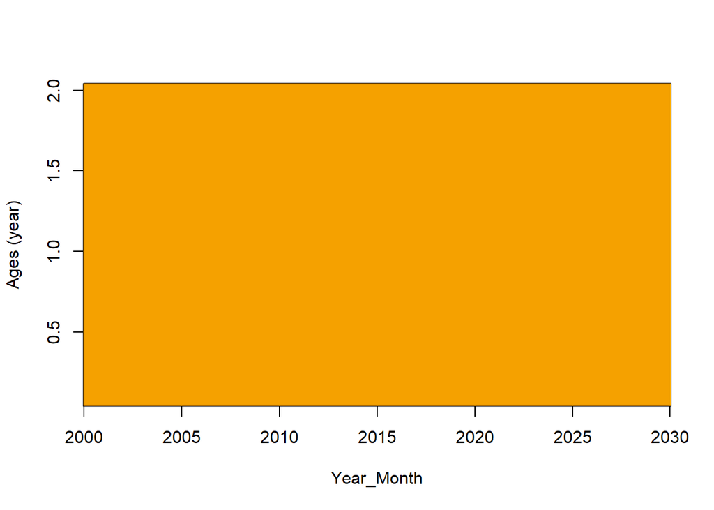

### 4.2.3 Figure 5. Recruitment before the starting time.

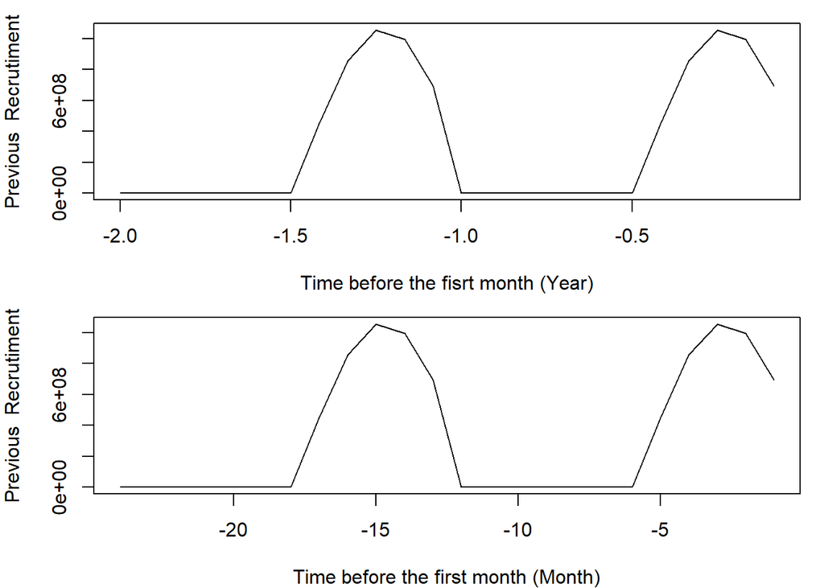

### 4.2.4 Figure 6. N at the first month.

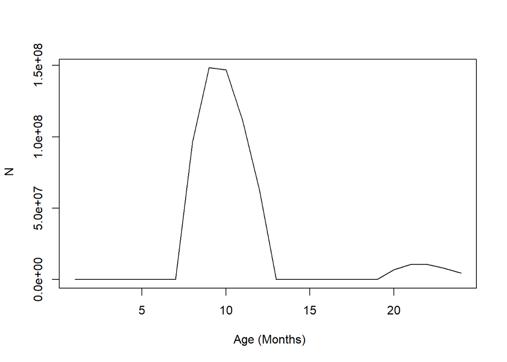

### 4.2.5 Figure 7. Seasonal recruitment patterns.

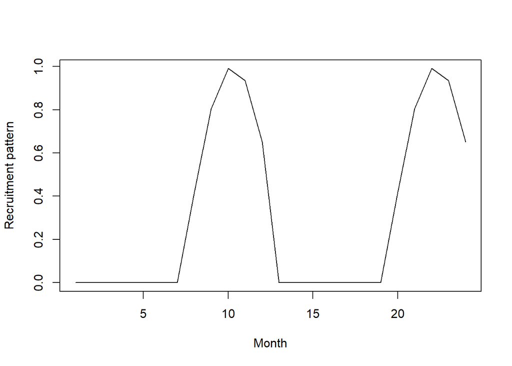

### 4.2.6 Figure 8. Fishing Selectivity by fleet.

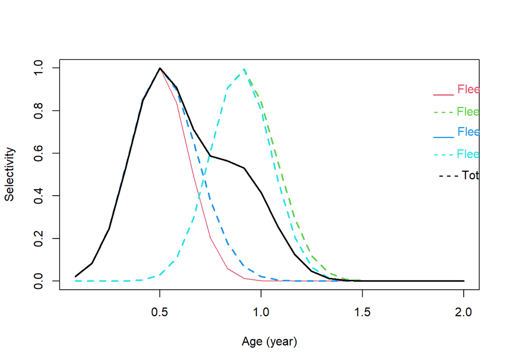

### 4.2.7 Figure 9. Spawning Biomass and Recruitment.

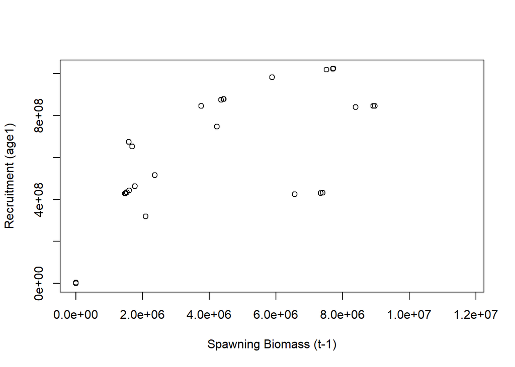

### 4.2.8 Figure 10. Seasonal Pattern of recruitment and Number at the beginning.

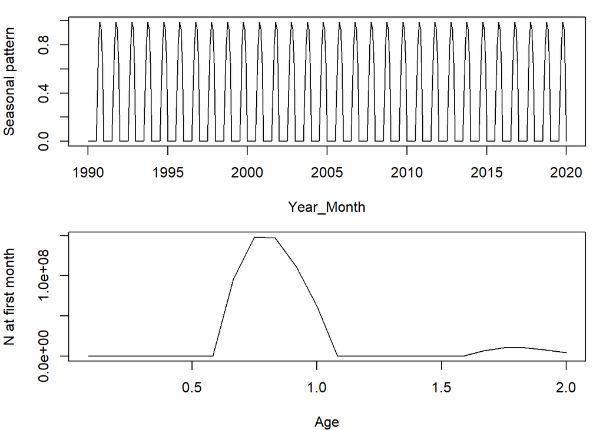

### 4.2.9 Figure 11. Number at age by YEAR.MONTH.

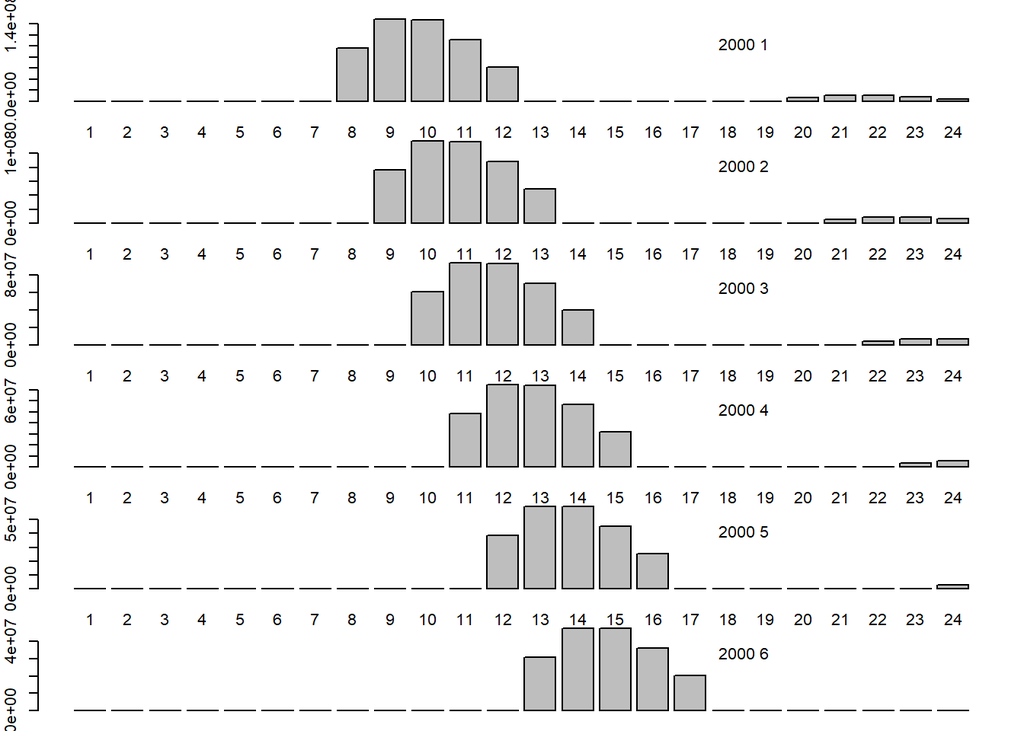

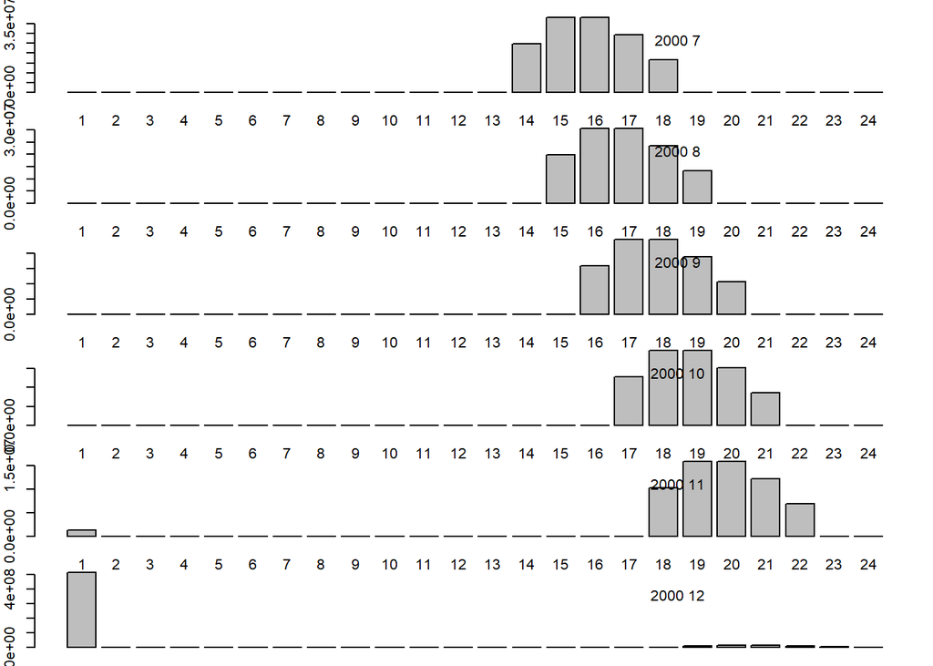

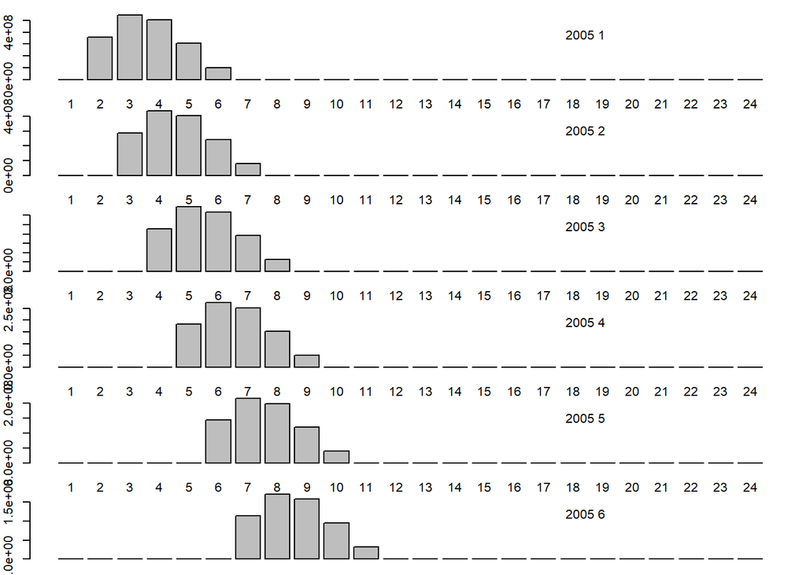

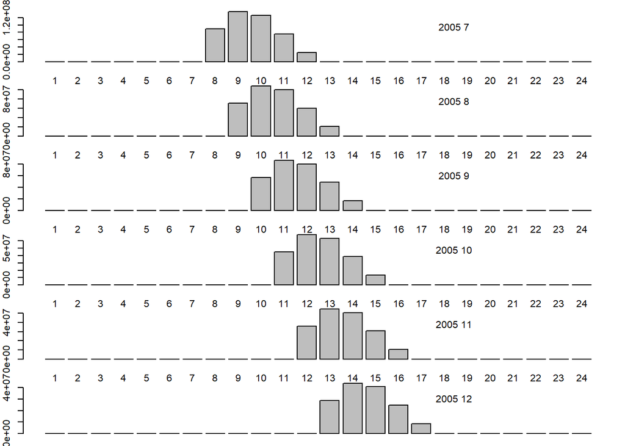

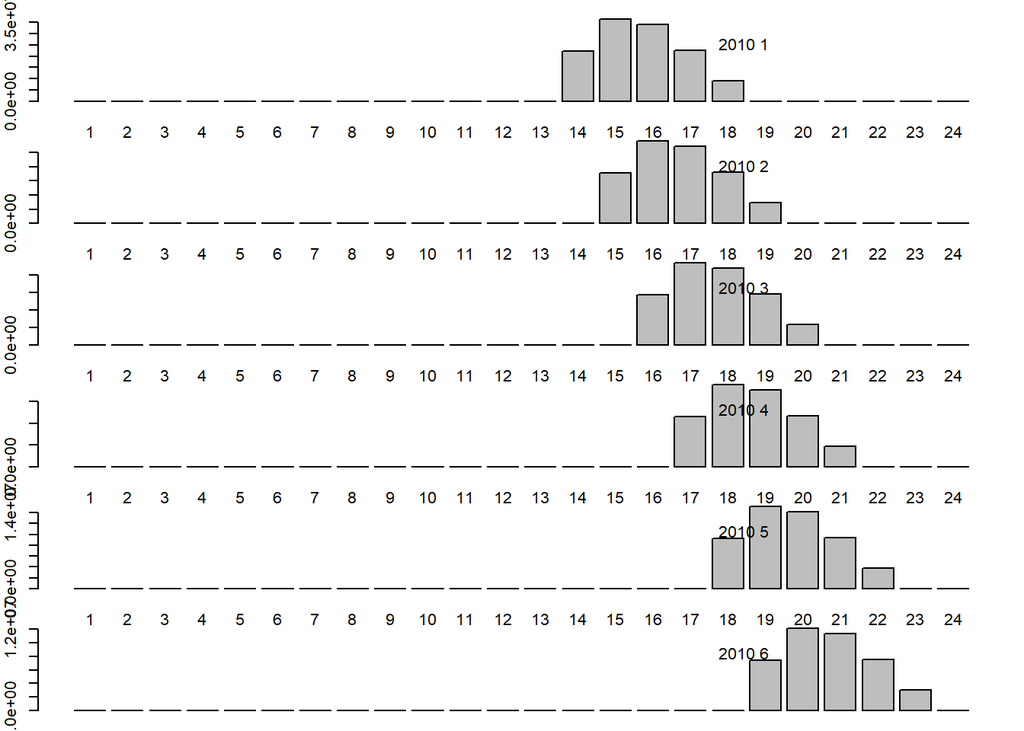

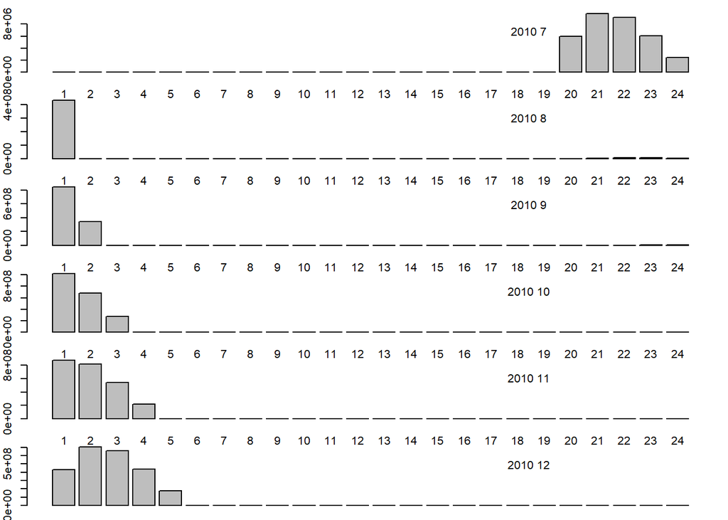

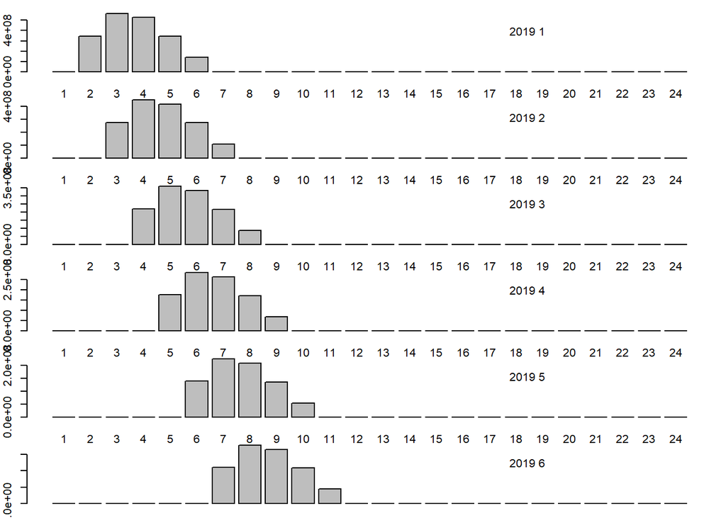

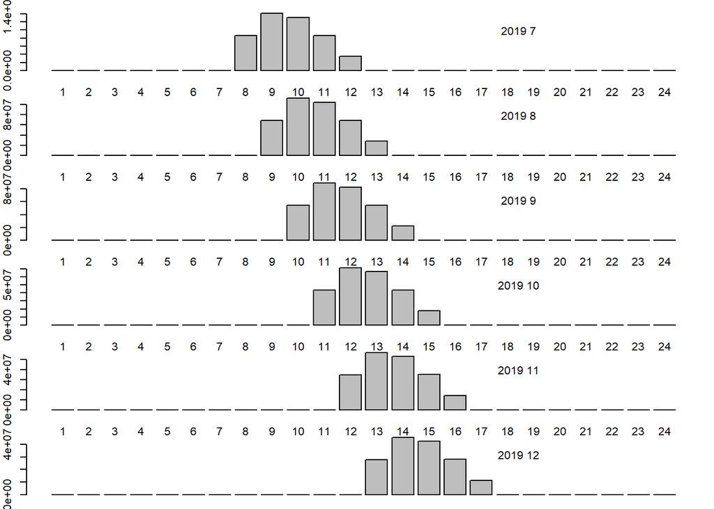

### 4.2.10 Figure 12. Whole Catch in number at age by YEAR.MONTH.

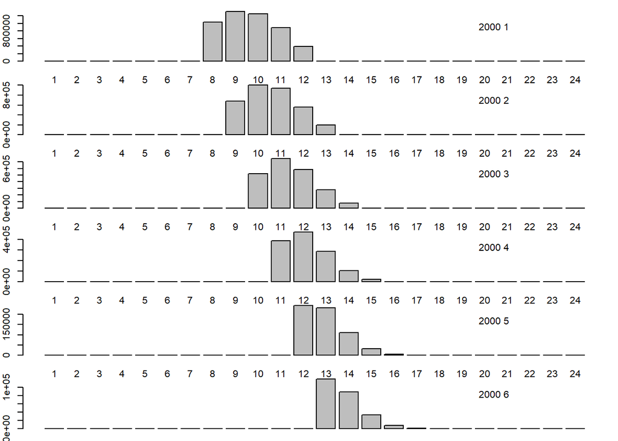

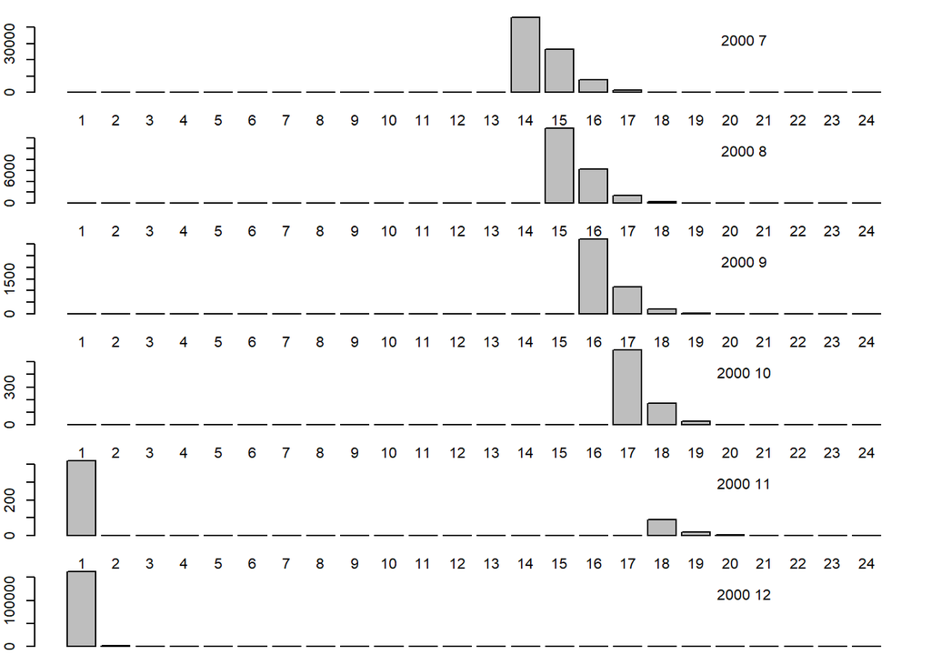

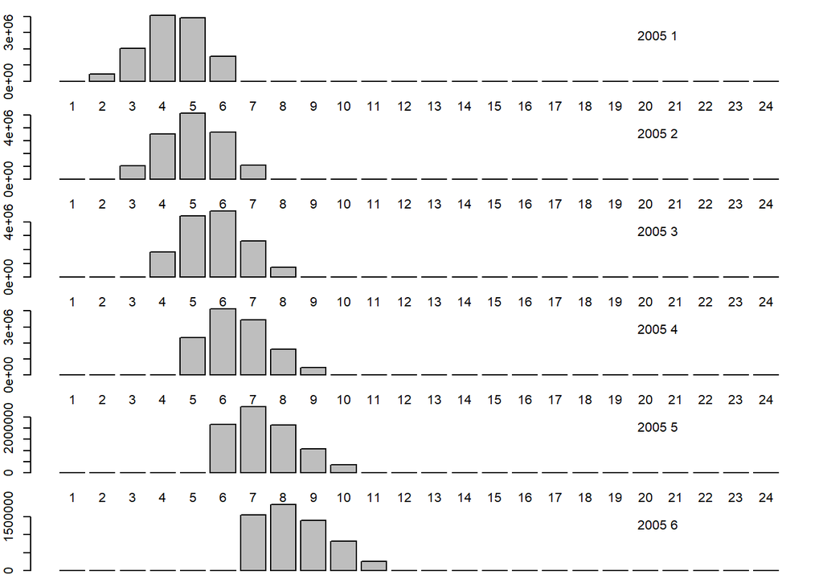

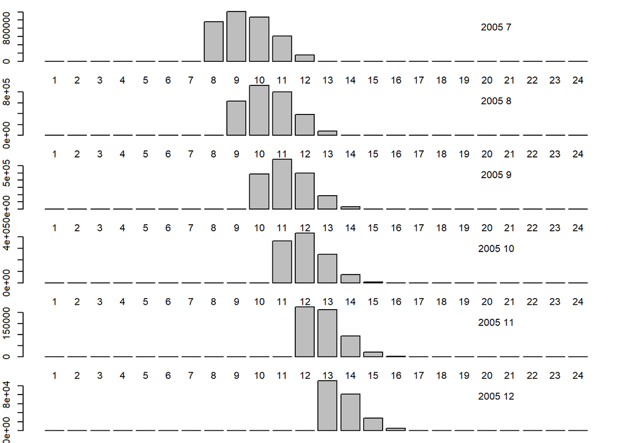

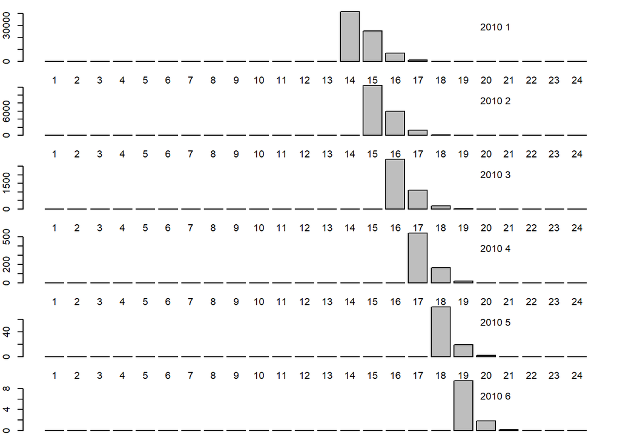

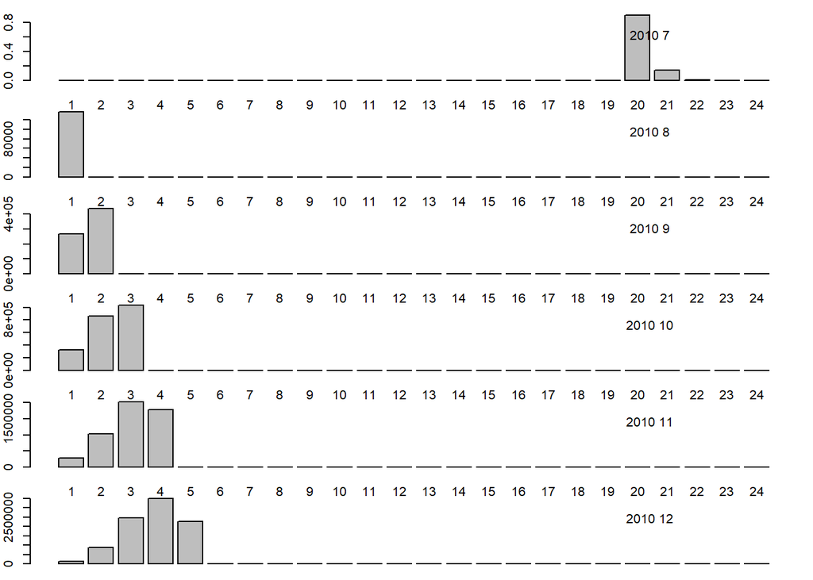

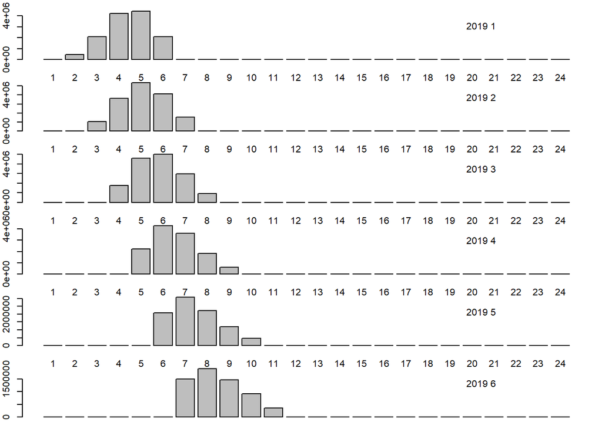

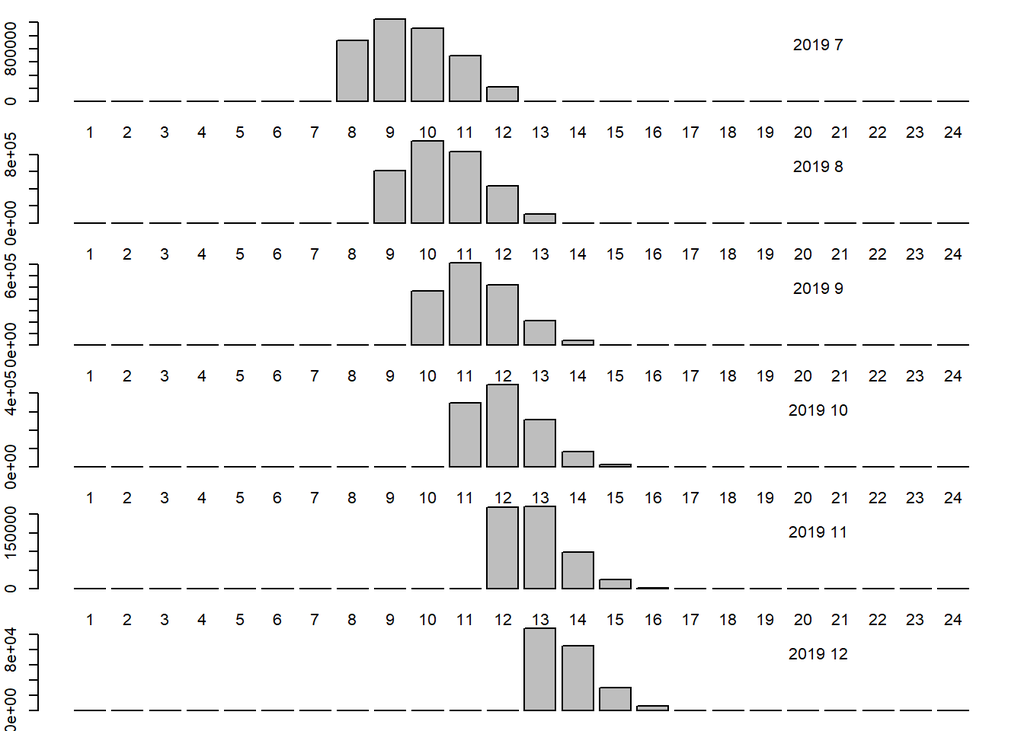

### 4.2.11 Figure 13. Fleet 1 Catch in number at age by YEAR.MONTH.

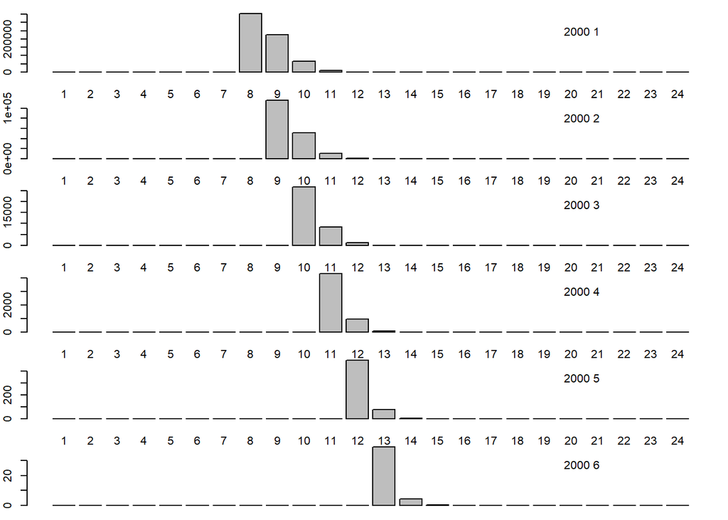

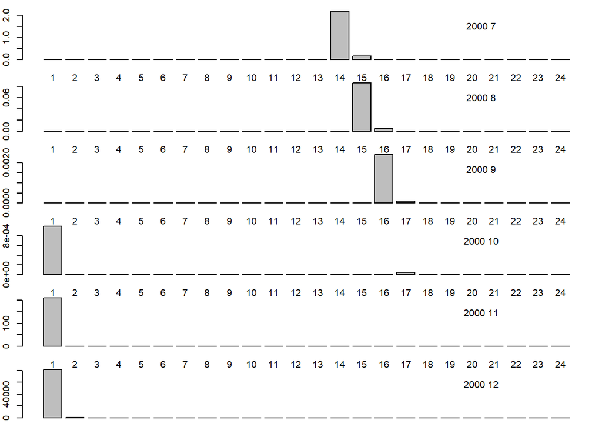

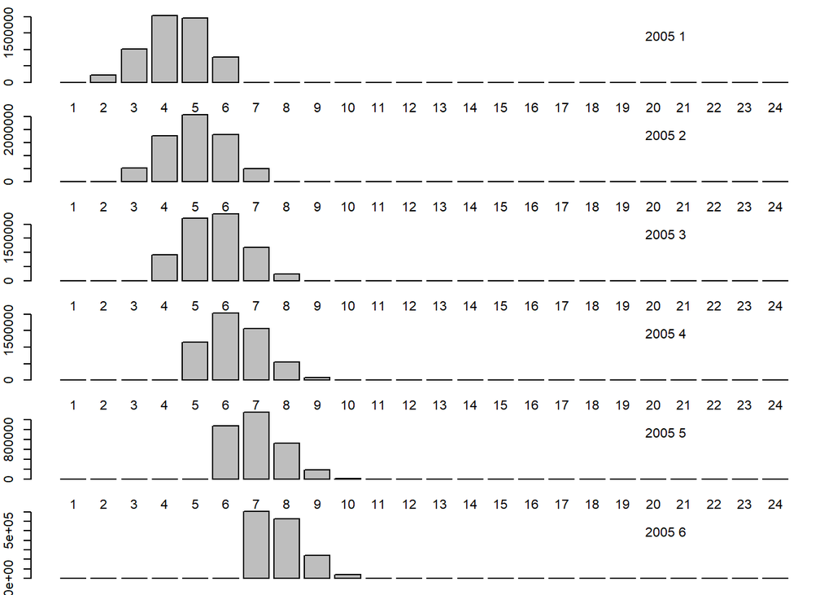

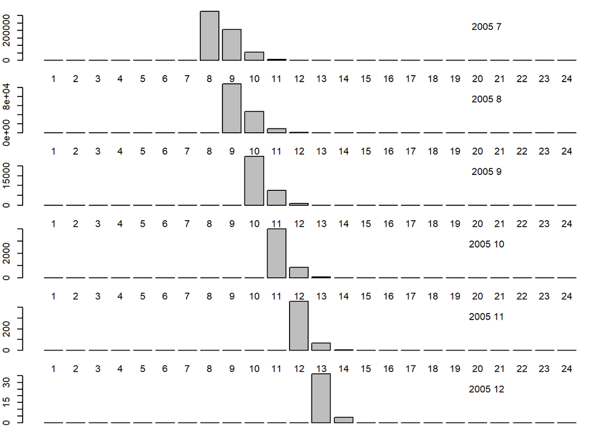